# Homework 4 Solutions

Alexandra Chronopoulou

## Multiple Linear Regression

### Part I: Practice Questions

1. A large national grocery retailer tracks productivity and cost of its facilities closely. The data in the `grocery.txt` file were obtained from a single distribution center for a one year period. Each data point for each variable represents one week of activity. The variables included are the number of cases shipped ($X_1$), the indirect costs of the total labor hours as a percentage ($X_2$), a qualitative predictor called holiday that is called in one of the week has a holy day and zero otherwise ($X_3$), and the total labor hours ($Y$).

   ```r
   library(ggplot2)
   library(faraway)
   grocery <- read.table("grocery.txt", header=FALSE)
   names(grocery) <- c("Y", "X1", "X2", "X3")
   grocery.full = lm(Y~., data=grocery)
   summary(grocery.full)
   ```

   ```
   ##
   ## Call:
   ## lm(formula = Y ~ ., data = grocery)
   ##
   ## Residuals:
   ##     Min      1Q  Median      3Q     Max
   ## -264.05 -110.73  -22.52   79.29  295.75
   ##
   ## Coefficients:
   ##               Estimate Std. Error t value Pr(>|t|)
   ## (Intercept)  4.150e+03  1.956e+02  21.220  < 2e-16 ***
   ## X1           7.871e-04  3.646e-04   2.159   0.0359 *
   ## X2          -1.317e+01  2.309e+01  -0.570   0.5712
   ## X3           6.236e+02  6.264e+01   9.954 2.94e-13 ***
   ## ---
   ## Signif. codes:  0 '***' 0.001 '**' 0.01 '*' 0.05 '.' 0.1 ' ' 1
   ##
   ## Residual standard error: 143.3 on 48 degrees of freedom
   ## Multiple R-squared:  0.6883, Adjusted R-squared:  0.6689
   ## F-statistic: 35.34 on 3 and 48 DF,  p-value: 3.316e-12
   ```

   1. Identify any outlying $Y$ observations. Use the Bonferroni outlier test procedure with $\alpha=.05$. State decision rule and conclusion.

      ```r
      jackknife=rstudent(grocery.full)
      n = dim(grocery)[1]
      p = 4 #dim(grocery)[2]
      qt(.05/(2*n), n-p-1)
      ```

      ```
      ## [1] -3.52308
      ```

      All of the residuals in absolute value are smaller than 3.52308. So, there are no outliers in this case.
   2. Obtain the diagonal elements of the hat matrix. Identify any high leverage points. If any, are they good or bad?

      ```r
      diag_hat = lm.influence(grocery.full)$hat
      diag_hat[diag_hat>(2*p/n)]
      ```

      ```
      ##         3         5        16        21        22        43        44        48
      ## 0.2188773 0.2063282 0.2554249 0.1936047 0.2577199 0.2868586 0.2200236 0.2817766
      ```

      Points 3,5,16,21,22,43,44,48 are all high leverage points.

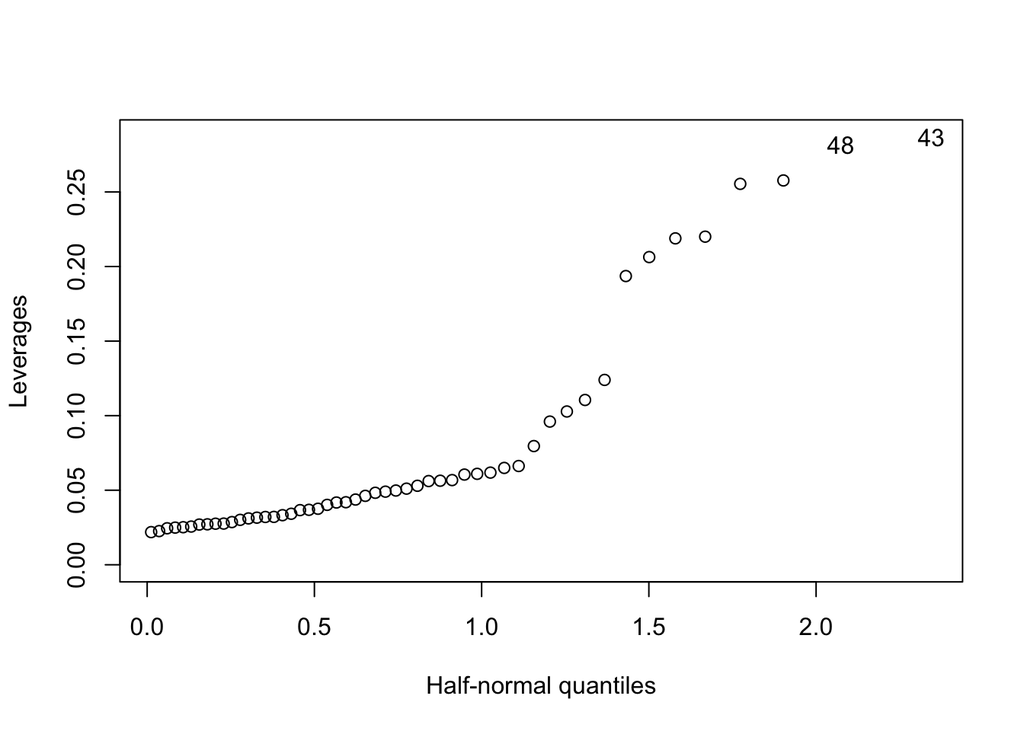

      ```r
      halfnorm(diag_hat, 2, ylab="Leverages")
      ```

      Based on the plot, we can say that all of these points have their $y$ coordinate shifted from the “line” which means that they are all bad high leverage points.
   3. Cases 16, 22, 43, and 48 appear to be outlying $X$ observations, and cases 10, 32, 38, and 40 appear to be outlying $Y$ observations. Obtain the Cook’s distance values for each of these cases to assess their influence. What do you conclude?

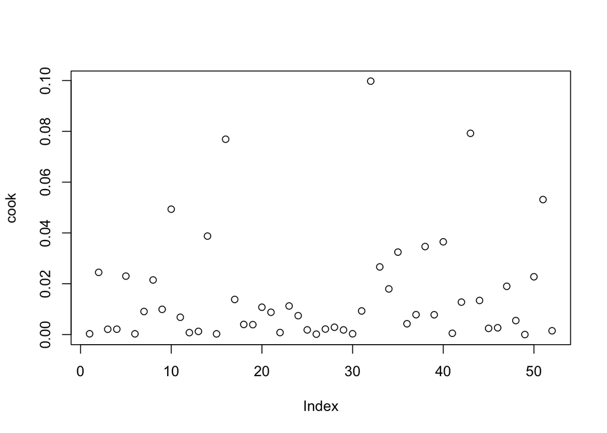

      ```r
      cook = cooks.distance(grocery.full)
      plot(cook)
      ```

      ```r
      c(cook[16], cook[22], cook[43], cook[48])
      ```

      ```
      ##           16           22           43           48
      ## 0.0768950835 0.0007746088 0.0792193145 0.0054988670
      ```

      ```r
      c(cook[10], cook[32], cook[38], cook[40])
      ```

      ```
      ##         10         32         38         40
      ## 0.04935012 0.09975974 0.03463803 0.03649915
      ```

      Their Cook’s is much less than 1, so there are no outlying observations in this data.
2. Use the `teengamb` data from the `faraway` library to fit a model with gamble as the response and the other variables as predictors.
   1. Predict the amount that a male with average (given this data) status, income and verbal score would gamble along with an appropriate 95% confidence interval.

      ```r
      library(ggplot2)
      library(faraway)
      data(teengamb)
      names(teengamb)
      ```

      ```
      ## [1] "sex"    "status" "income" "verbal" "gamble"
      ```

      ```r
      attach(teengamb)

      teengamb.full = lm(gamble~., data=teengamb)
      summary(teengamb.full)
      ```

      ```
      ##
      ## Call:
      ## lm(formula = gamble ~ ., data = teengamb)
      ##
      ## Residuals:
      ##     Min      1Q  Median      3Q     Max
      ## -51.082 -11.320  -1.451   9.452  94.252
      ##
      ## Coefficients:
      ##              Estimate Std. Error t value Pr(>|t|)
      ## (Intercept)  22.55565   17.19680   1.312   0.1968
      ## sex         -22.11833    8.21111  -2.694   0.0101 *
      ## status        0.05223    0.28111   0.186   0.8535
      ## income        4.96198    1.02539   4.839 1.79e-05 ***
      ## verbal       -2.95949    2.17215  -1.362   0.1803
      ## ---
      ## Signif. codes:  0 '***' 0.001 '**' 0.01 '*' 0.05 '.' 0.1 ' ' 1
      ##
      ## Residual standard error: 22.69 on 42 degrees of freedom
      ## Multiple R-squared:  0.5267, Adjusted R-squared:  0.4816
      ## F-statistic: 11.69 on 4 and 42 DF,  p-value: 1.815e-06
      ```

      ```r
      average_status = mean(status)
      average_income = mean(income)
      average_verbal = mean(verbal)
      newdata1= data.frame(sex=0, status=average_status, income=average_income, verbal=average_verbal)
      predict(teengamb.full, new=newdata1, interval='confidence')
      ```

      ```
      ##        fit      lwr      upr
      ## 1 28.24252 18.78277 37.70227
      ```

   2. Repeat the prediction for a male with maximal values (for this data) of status income and verbal score. Which confidence interval is wider and why? Is this result expected?

      ```r
      max_status = max(status)
      max_income = max(income)
      max_verbal = max(verbal)
      newdata2= data.frame(sex=0, status=max_status, income=max_income, verbal=max_verbal)
      predict(teengamb.full, new=newdata2, interval='confidence')
      ```

      ```
      ##        fit      lwr      upr
      ## 1 71.30794 42.23237 100.3835
      ```

   3. Fit a model with $\sqrt{gamble}$ as a response but with the same predictors. Now predict the response and give a 95% prediction interval for the individual in (a). Take care to give your answer in the original units of the response.

      ```r
      sqrt_gamble = sqrt(gamble)
      teengamb.reg = lm(sqrt_gamble~sex+status+income+verbal, data=teengamb)
      summary(teengamb.reg)
      ```

      ```
      ##
      ## Call:
      ## lm(formula = sqrt_gamble ~ sex + status + income + verbal, data = teengamb)
      ##
      ## Residuals:
      ##     Min      1Q  Median      3Q     Max
      ## -4.6606 -1.0961 -0.2564  0.9786  5.4178
      ##
      ## Coefficients:
      ##             Estimate Std. Error t value Pr(>|t|)
      ## (Intercept)  2.97707    1.57947   1.885  0.06638 .
      ## sex         -2.04450    0.75416  -2.711  0.00968 **
      ## status       0.03688    0.02582   1.428  0.16057
      ## income       0.47938    0.09418   5.090 7.94e-06 ***
      ## verbal      -0.42360    0.19950  -2.123  0.03967 *
      ## ---
      ## Signif. codes:  0 '***' 0.001 '**' 0.01 '*' 0.05 '.' 0.1 ' ' 1
      ##
      ## Residual standard error: 2.084 on 42 degrees of freedom
      ## Multiple R-squared:  0.5646, Adjusted R-squared:  0.5231
      ## F-statistic: 13.61 on 4 and 42 DF,  p-value: 3.362e-07
      ```

      ```r
      average_status = mean(status)
      average_income = mean(income)
      average_verbal = mean(verbal)
      newdata1= data.frame(sex=0, status=average_status, income=average_income, verbal=average_verbal)
      predict(teengamb.reg, new=newdata1, interval='prediction')
      ```

      ```
      ##        fit       lwr      upr
      ## 1 4.049523 -0.245035 8.344082
      ```

      ```r
      predict(teengamb.reg, new=newdata1, interval='prediction')^2
      ```

      ```
      ##        fit        lwr     upr
      ## 1 16.39864 0.06004216 69.6237
      ```

   4. Repeat the prediction for the model in (c) for a female with status= 20, income = 1, verbal=10. Comment on the credibility of the result.

      ```r
       newdata4= data.frame(sex=1, status=20, income=1, verbal=10)
      predict(teengamb.reg, new=newdata4, interval='prediction')
      ```

      ```
      ##        fit       lwr      upr
      ## 1 -2.08648 -6.908863 2.735903
      ```

      ```r
      predict(teengamb.reg, new=newdata4, interval='prediction')^2
      ```

      ```
      ##        fit      lwr      upr
      ## 1 4.353398 47.73238 7.485167
      ```

      The result is not credible.
   5. Using the model with gamble as the response, check for large leverage points, outliers, and influential points.

      ```r
      jackknife=rstudent(teengamb.full)
      sort(abs(jackknife), decreasing=TRUE)[1:5]
      ```

      ```
      ##       24       39       36        5       18
      ## 6.016116 2.506090 2.144826 1.418583 1.317398
      ```

      ```r
      n = dim(teengamb)[1]
      p = dim(teengamb)[2]
      qt(.05/(2*n), n-p-1)
      ```

      ```
      ## [1] -3.522795
      ```

      Case 24 has the studentized residual in absolute value larger than 3.522795. So, case 24 is an outlier.

      ```r
      diag_hat = lm.influence(teengamb.full)$hat
      diag_hat[diag_hat>(2*p/n)]
      ```

      ```
      ##        31        33        35        42
      ## 0.2395031 0.2213439 0.3118029 0.3016088
      ```

      So point 31, 33, 35, and 42 are high leverage points.

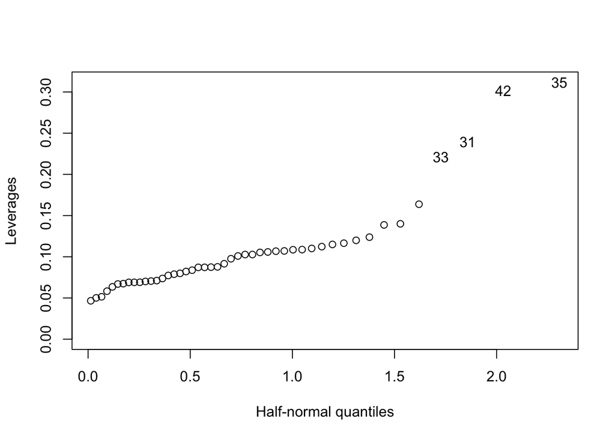

      ```r
      halfnorm(diag_hat, 4, ylab="Leverages")
      ```

      From the plot we know all of these points have the y shifted away on the rough line, which means all of them are bad high leverage points.

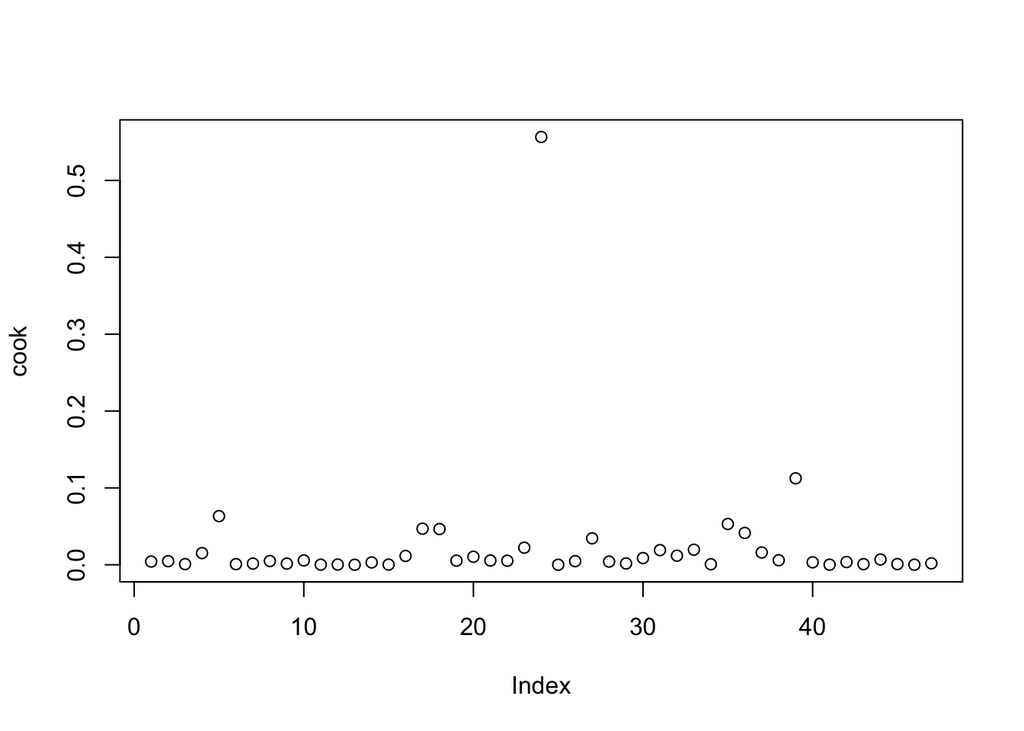

      ```r
      cook = cooks.distance(teengamb.full)
      plot(cook)
      ```

      There are no influential values here since none of the Cook’s distance are greater or equal to 1.

### Part II: Homework Questions

The `whitewines.csv` data set contains information related to white variants of the Portuguese “Vinho Verde” wine. Specifically, we have recorded the following information:

1. fixed acidity, (b) volatile acidity, (c) citric acid, (d) residual sugar, (e) chlorides , (f) free sulfur dioxide, (g) total sulfur dioxide, (h) density, (i) pH, (j) sulphates, (k) alcohol, (l) quality (score between 0 and 10)

In this homework, our goal is to explain the relationship between alcohol level (dependent variable) and residual sugar, pH, density and fixed acidity.

```r
whitewines = read.csv("whitewines.csv", sep = ";")
```

1. Identify any outlying $Y$ observations. Use the Bonferroni outlier test procedure with $\alpha=.05$. State decision rule and conclusion.

   ```r
   full_wine = lm(alcohol ~ residual.sugar + pH + density + fixed.acidity, data = whitewines)
   n = dim(whitewines)[1]
   p=5
   qt(.05/(2*n), n-p-1)
   ```

   ```
   ## [1] -4.417336
   ```

   ```r
   wine.resid = rstudent(full_wine)
   sort(abs(wine.resid), decreasing = TRUE)[1:10]
   ```

   ```
   ##      2782      3902      1527      1654      1664      1418      2732      3620
   ## 43.513422  8.425736  7.325843  6.464412  6.464412  4.103559  4.093453  4.068846
   ##      3624      2731
   ##  4.068846  4.060125
   ```

   We start by fitting the full model. Then, we extract the studentized residuals needed to perform the Bonferroni outlier test. We compute the t-distribution value with degrees of freedom $n-p-1$. We observe that the 5 highest values of the residuals are greater (in absolute value) than 4.42, which means that we have 5 outliers, that is observations in rows 2782, 3902, 1527, 1654, 1664.
2. Obtain the diagonal elements of the hat matrix and identify any high leverage points. If any, are they good or bad?

   We use the lm.influence function to compute the leverages (i.e. the diagonal elements of the hat matrix).

   ```r
   lev = lm.influence(full_wine)$hat
   head(lev)
   ```

   ```
   ##            1            2            3            4            5            6
   ## 0.0019801090 0.0010926160 0.0009988590 0.0002865956 0.0002865956 0.0009988590
   ```

   ```r
   leverages = lev[lev>(2*p/n)]
   head(leverages)
   ```

   ```
   ##          15          32          73          99         116         170
   ## 0.002069166 0.002601884 0.002970866 0.003260806 0.002446706 0.003052161
   ```

   We observe that we have many high leverage points. In fact, we find that about 5% of the observations are high leverage points.

   ```r
   length(leverages) / n
   ```

   ```
   ## [1] 0.05042875
   ```

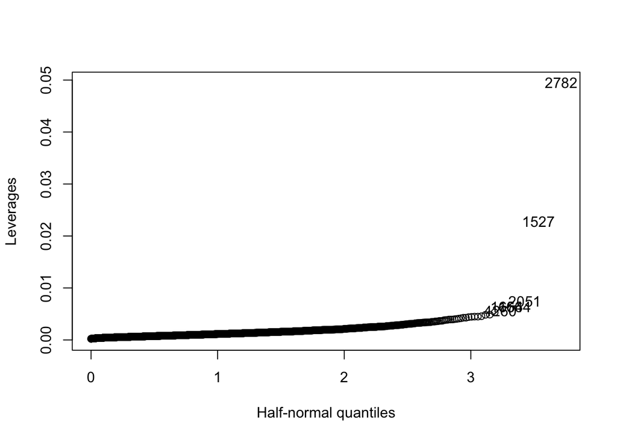

   ```r
    library(faraway)
   halfnorm(lev, 6, labs=as.character(1:length(lev)), ylab = "Leverages")
   ```

   Using the half-norm plot, we find that we have at least two bad high leverage points, i.e. observations 1527 and 2782.
3. Use Cook’s distance to investigate whether there are any high influential points. What do you conclude?

   ```r
   cooks = cooks.distance(full_wine)
   sort(cooks, decreasing = TRUE)[1:10]
   ```

   ```
   ##         2782         1527         1654         1664         3902         3620
   ## 14.232508181  0.247248953  0.053465084  0.053465084  0.031188148  0.011067253
   ##         3624         2731         1952         2732
   ##  0.011067253  0.007939572  0.007433765  0.006609749
   ```

   Using our rule of thumb, we only have one highly influential observation (an obs with cook’s distance greater than 1), observation 2782.
4. Calculate Cook’s distance $D_i$ for each case and prepare an index plot. Are any cases influential according to this measure?

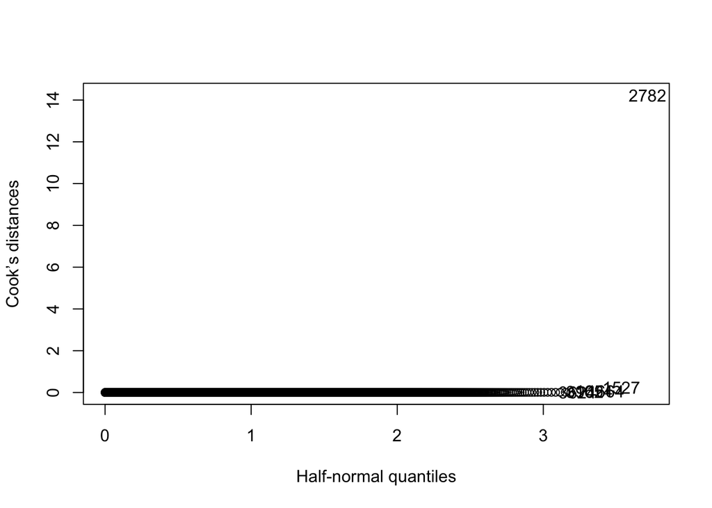

   ```r
   halfnorm(cooks, 6, labs=as.character(1:length(cooks)), ylab = "Cook’s distances")
   ```

   Our previous conclusion is also reached by looking at the halfnormal plot.
5. Predict the amount of alcohol of a white wine with residual.sugar = 1.7 , pH = 3, density = 1, fixed.acidity = 6.3 with an appropriate 95% confidence interval.

   ```r
   predict( full_wine, data.frame( residual.sugar = 1.7, pH = 3, density = 1, fixed.acidity = 6.3), level = .95, interval = "confidence")
   ```

   ```
   ##        fit      lwr      upr
   ## 1 4.533544 4.440764 4.626325
   ```

6. Predict the amount of alcohol of a white wine with residual.sugar = 67 , pH = 4, density = 1.1, fixed.acidity = 15 with an appropriate 95% prediction interval.

   ```r
   predict( full_wine, data.frame( residual.sugar = 67, pH = 4, density = 1.1, fixed.acidity = 15),level = .95,interval = "prediction")
   ```

   ```
   ##         fit       lwr       upr
   ## 1 -41.40047 -42.52562 -40.27533
   ```

   We observe that this interval is negative which might seem wrong. Mathematically, the calculations are correct. However, statistically in order to obtain this interval we did an extrapolation, since the values of the predictors are all outside the range of the values that we have already observed.
7. Construct a 95% confidence region for the slope coefficients of pH and density. What do you conclude about the statistical significance of $\beta_{pH}$ and $\beta_{density}$?

   ```r
   library(ellipse)
   ```

   ```r
   library(ggplot2)
   CR95 = ellipse(full_wine, c(3,4), level = .95)
   ```

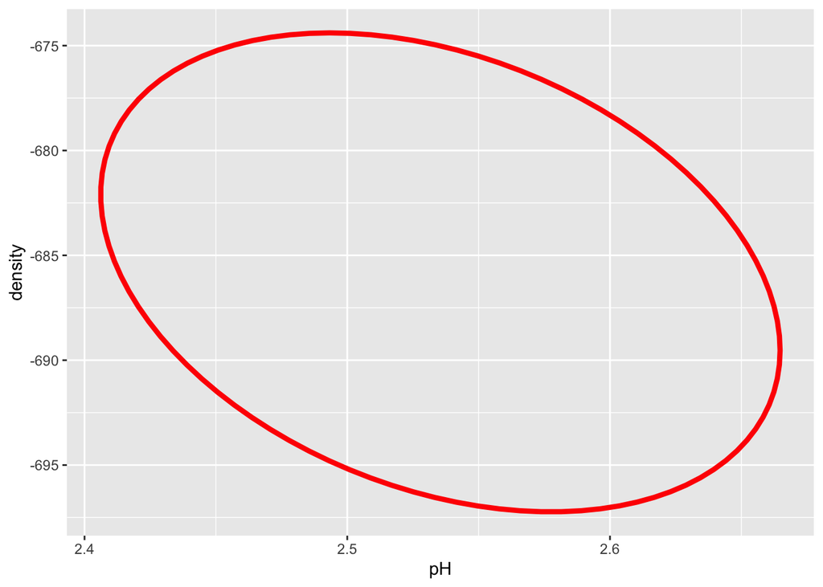

   ```r
   ggplot(data = as.data.frame(CR95), aes(x = pH, y = density)) +
     geom_path(col = "red", size = 1.5)
   ```

   The point (0,0) is not included in the confidence region which means that at least one of the betas is not equal to zero, or in other words at least one of the variables pH or density is statistically significant.
8. Regress `alcohol` against `fixed acidity` and construct a 95% simultaneous confidence band for the fitted regression line.

   In the following examples, we fit a SLR model with alcohol as the response and fixed.acidity as the predictor.

   ```r
   wine.slr = lm(alcohol ~ fixed.acidity, data = whitewines)
   summary(wine.slr)
   ```

   ```
   ##
   ## Call:
   ## lm(formula = alcohol ~ fixed.acidity, data = whitewines)
   ##
   ## Residuals:
   ##     Min      1Q  Median      3Q     Max
   ## -2.9823 -1.0768 -0.1356  0.8699  3.6056
   ##
   ## Coefficients:
   ##               Estimate Std. Error t value Pr(>|t|)
   ## (Intercept)   11.72264    0.14289  82.041   <2e-16 ***
   ## fixed.acidity -0.17628    0.02069  -8.521   <2e-16 ***
   ## ---
   ## Signif. codes:  0 '***' 0.001 '**' 0.01 '*' 0.05 '.' 0.1 ' ' 1
   ##
   ## Residual standard error: 1.222 on 4896 degrees of freedom
   ## Multiple R-squared:  0.01461,    Adjusted R-squared:  0.01441
   ## F-statistic:  72.6 on 1 and 4896 DF,  p-value: < 2.2e-16
   ```

   We will construct step-by-step the confidence band as it is shown in Lecture 7, slide 17.

   The $\hat{r}$ term is

   ```r
   estimates = summary(wine.slr)$coefficients[1, 1] + summary(wine.slr)$coefficients[2,1]*whitewines[,1]
   ```

   while term $c$ computes as:

   ```r
   c = sqrt(2 * qf(.05, 2, n - 2, lower.tail = FALSE))
   ```

   Finally, we compute the estimated $\sigma$, ie. $\hat{\sigma}$:

   ```r
   sigma = summary(wine.slr)$sigma * sqrt((1/n) +((whitewines[,1] - mean(whitewines[,1]))^2)/sum((whitewines[, 1]-mean(whitewines[,1]))^2))
   ```

   We combine the above the estimator, lower and upper bounds in a data frame:

   ```r
   confidence.band = cbind(estimates, lower = estimates - c*sigma, upper = estimates + c*sigma)
   head(confidence.band)
   ```

   ```
   ##      estimates    lower    upper
   ## [1,]  10.48867 10.44530 10.53204
   ## [2,]  10.61207 10.56091 10.66322
   ## [3,]  10.29476 10.21856 10.37095
   ## [4,]  10.45341 10.40723 10.49959
   ## [5,]  10.45341 10.40723 10.49959
   ## [6,]  10.29476 10.21856 10.37095
   ```

9. Plot the raw data corresponding to question (h), fitted regression line, 95% point-wise confidence intervals and 95% confidence band calculated in (h). What do you observe?

   The following chunk of code computes the pointwise confidence intervals according to lecture 7 again. Note that the point estimates are the same as well as the standard error. What changes is the multiplier.

   ```r
   t = qt(.025, n-2)
   pointwise.interval = cbind(estimates, lower = estimates + t*sigma, upper = estimates - t*sigma)
   head(pointwise.interval)
   ```

   ```
   ##      estimates    lower    upper
   ## [1,]  10.48867 10.45394 10.52339
   ## [2,]  10.61207 10.57111 10.65302
   ## [3,]  10.29476 10.23375 10.35577
   ## [4,]  10.45341 10.41644 10.49039
   ## [5,]  10.45341 10.41644 10.49039
   ## [6,]  10.29476 10.23375 10.35577
   ```

   Finally, we plot together: the raw data, regression line (green), confidence band (blue), pointwise intervals (magenta):

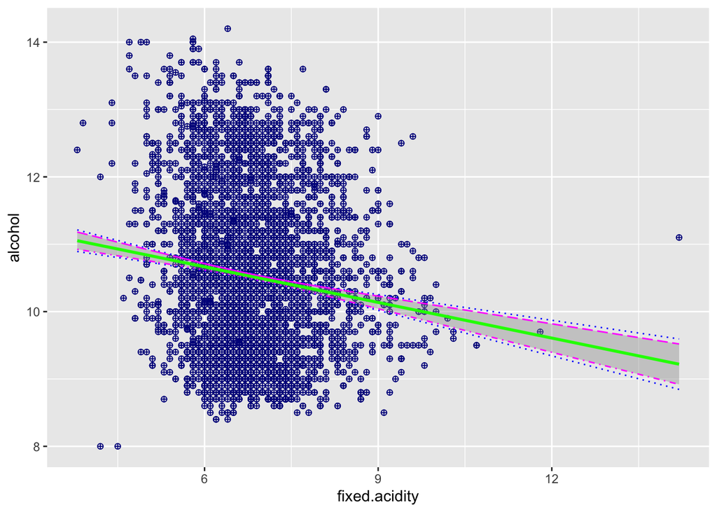

   ```r
   ggplot(data = whitewines, aes(x=fixed.acidity, y = alcohol)) +
     geom_point(col = "darkblue", pch = 10) +
     geom_smooth(method = "lm", formula = y~x, col="green") +
     geom_line(aes(y=confidence.band[,2]), col = "blue",  linetype=3) +
     geom_line(aes(y=confidence.band[,3]), col = "blue", linetype=3) +
     geom_line(aes(y=pointwise.interval[,2]), col = "magenta",   linetype=4) +
     geom_line(aes(y=pointwise.interval[,3]), col = "magenta",   linetype=5)
   ```

   As we expected, the confidence band is slightly wider than the pointwise intervals.